# Assignment 8: Bayes Probabilities & HDI

Univeristy of Washington - Data Science Certification - Method for Data Analysis

Josh Jensen

August 22, 2016

### Assignment

Compute the probability that the driver of a car is texting at a specific intersection, given the following:

- Nationally the chance that a driver is texting is:
  - P = 0.5, at x = 0.1
  - P = 0.75 at x = 0.3
- You observe cars at a location three times and note the number of texting drivers:
  - 2 texting out of 20 drivers
  - 4 texting out of 20 drivers
  - 1 texting out of 20 drivers

Given these data:

- Compute the Beta prior, and report the coefficents
- Plot the prior, likelihood and posterior three times as you update your belief based on collecting more data
- Simulate the final posterior distribution and do the following:
  - Plot the posterior with the 90% HDI shown
  - Report the upper and lower limits of the 90% HDI
  - Of the next hundred drivers what are the number of texting drivers in the 90% HDI?
  - Are the drivers in this area better or worse that the national figures indicate?

### Conclusions

Further we conclude that the drivers observed in the area are worse than what the national figures indicate.

### Set up

Load `LearnBayes` and set prior distribution.

```r
library(LearnBayes)

beta_prior <- beta.select(list(p=.5, x=.1), list(p=.75, x=.3))
beta_prior
```

```
## [1] 0.41 1.73
```

Now 2 texting out of 20 drivers are observed. We update our beliefs.

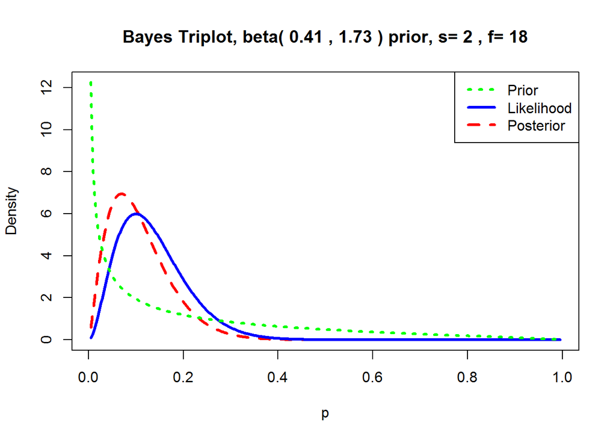

```r
triplot(beta_prior, c(2, 18), where = 'topright')
```

```r
beta_prior + c(2, 18)
```

```
## [1]  2.41 19.73
```

Now 4 texting out of 20 drivers are observed. Again, we update our beliefs.

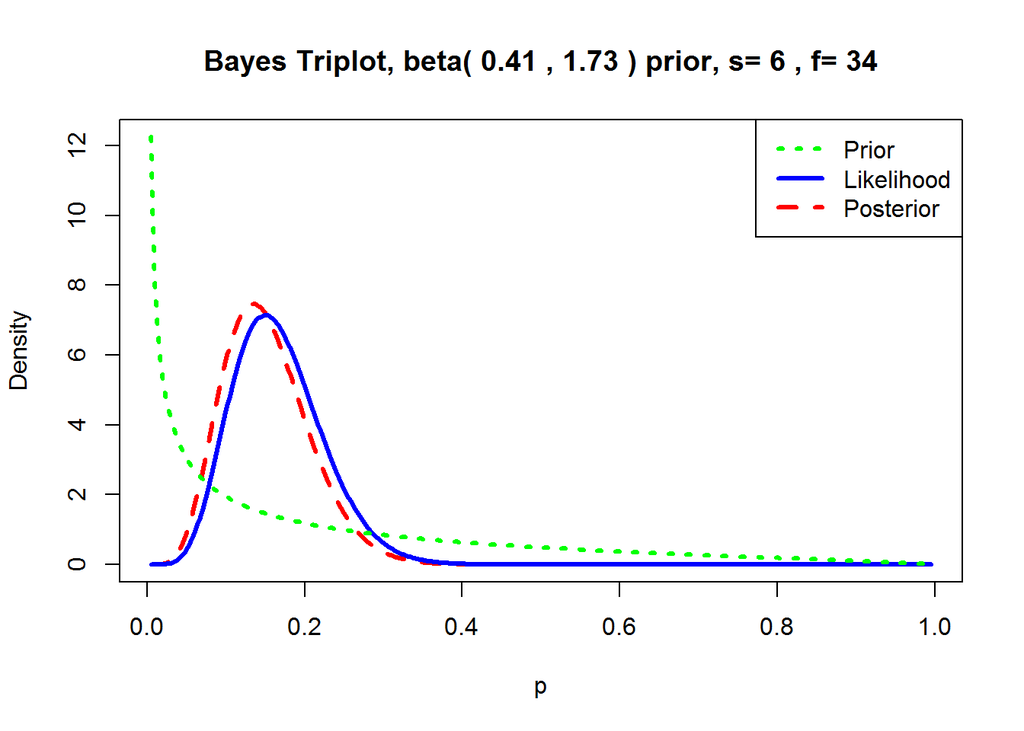

```r
triplot(beta_prior, c(2 + 4, 18 + 16), where = 'topright')
```

```r
beta_prior + c(2 + 4, 18 + 16)
```

```
## [1]  6.41 35.73
```

Now 1 texting out of 20 drivers are observed. We update our beliefs for a final time.

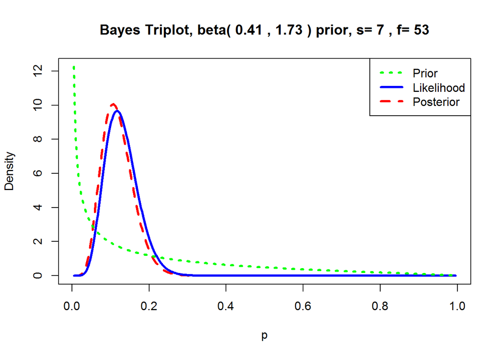

```r
triplot(beta_prior, c(2 + 4 + 1, 18 + 16 + 19), where = 'topright')
```

```r
beta_prior + c(2 + 4 + 1, 18 + 16 + 19)
```

```
## [1]  7.41 54.73
```

### Evaluate posterior results

First calculate the posterior beta distribution.

```r
beta_post <- beta_prior + c(2 + 4 + 1, 18 + 16 + 19)
```

Compute a random sample of 100,000 observations from the posterior distribution.

```r
post_sample <- rbeta(100000, beta_post[1], beta_post[2])
```

Now report the 90% HDI limits and plot a histogram the random sample.

```r
# calc hdi limits
quants <- quantile(post_sample, c(0.05, 0.95))
quants
```

```
##         5%        95%
## 0.05962961 0.19207542
```

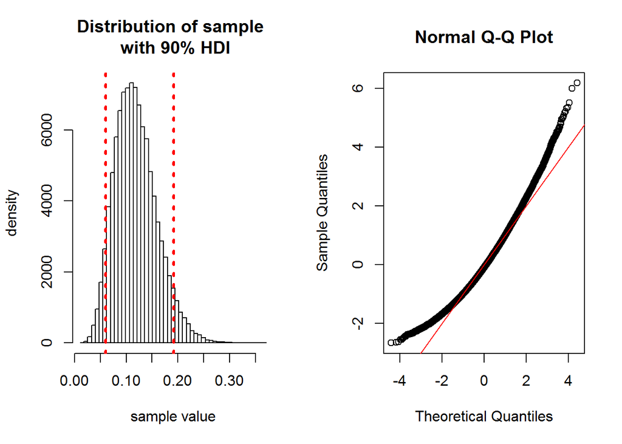

```r
# plot
par(mfrow = c(1, 2))

quants <- quantile(post_sample, c(0.05, 0.95))
breaks <- seq(min(post_sample), max(post_sample), length.out = 50)
hist(post_sample, breaks = breaks,
     main = "Distribution of sample \n with 90% HDI"
     , xlab = "sample value"
     , ylab = "density")
abline(v = quants[1], lty = 3, col = "red", lwd = 3)
abline(v = quants[2], lty = 3, col = "red", lwd = 3)

qqnorm(scale(post_sample))
abline(a=0, b=1, col = 'red')
```

```r
par(mfrow = c(1, 1))
```

Finally compare to national figures by comparing the initial figures and reinspecting the plot of the prior and final posterior distribution.

```r
pbeta(c(.1, .3), beta_post[1], beta_post[2])
```

```
## [1] 0.3484589 0.9997342
```

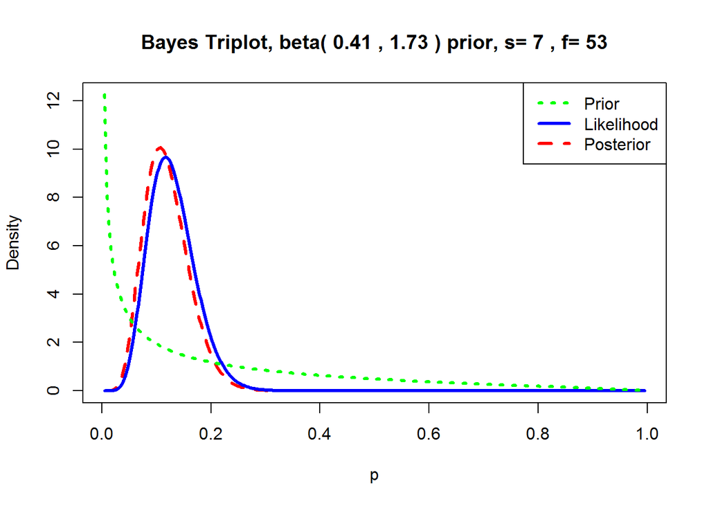

```r
triplot(beta_prior, c(2 + 4 + 1, 18 + 16 + 19), where = 'topright')
```

Note that the posterior distribution is skewed towards higher probabilities of texting. Hence, we conclude that the drivers observed in the area are worse than what the national figures indicate.